# Reproducible Research: Project 1: Steps

Samantha Neeno

December 5, 2016

PA1_template.Rmd

## Loading and preprocessing the data

1. Load the data (i.e. read.csv())

```r
require(RCurl)
library(dplyr) ## Library is required for the "filter function"
library(chron)

download.file("https://github.com/rdpeng/RepData_PeerAssessment1/blob/master/activity.zip", destfile="activity.zip", mode="wb")
unzip(zipfile = 'activity.zip')
activityData <- read.csv('activity.csv')

head(activityData)
```

```
##   steps       date interval
## 1    NA 2012-10-01        0
## 2    NA 2012-10-01        5
## 3    NA 2012-10-01       10
## 4    NA 2012-10-01       15
## 5    NA 2012-10-01       20
## 6    NA 2012-10-01       25
```

2. Process/transform the data (if necessary) into a format suitable for your analysis

```r
# Convert the factor "date" to an actual date
activityData$date<-as.Date(activityData$date)

# Eliminate individual rows that are empty, independent of day
rmNA_activityData <- subset(activityData, !is.na(activityData$steps))
```

## What is mean total number of steps taken per day?

*For this part of the assignment, you can ignore the missing values in the dataset, eliminate them.*

1. Calculate the total number of steps taken per day

```r
# Sum total steps per day
rmNA_activityData_DateSum<-aggregate.data.frame(rmNA_activityData$steps,by=list(rmNA_activityData$date),FUN=sum, simplify = TRUE)

colnames(rmNA_activityData_DateSum) <- c("date","steps")

head(rmNA_activityData_DateSum)
```

```
##         date steps
## 1 2012-10-02   126
## 2 2012-10-03 11352
## 3 2012-10-04 12116
## 4 2012-10-05 13294
## 5 2012-10-06 15420
## 6 2012-10-07 11015
```

2. If you do not understand the difference between a histogram and a barplot, research the difference between them. Make a histogram of the total number of steps taken each day

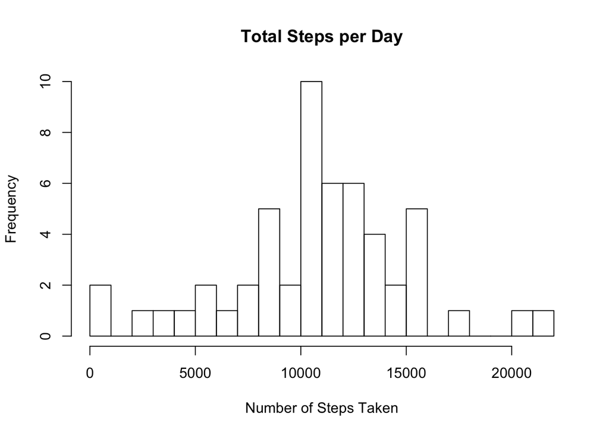

```r
hist(rmNA_activityData_DateSum$steps, xlab="Number of Steps Taken",ylab="Frequency",main ="Total Steps per Day", breaks = 20)
```

3. Calculate and report the mean and median of the total number of steps taken per day

```r
mean(rmNA_activityData_DateSum$steps,na.rm = TRUE)
```

```
## [1] 10766.19
```

```r
median(rmNA_activityData_DateSum$steps,na.rm = TRUE)
```

```
## [1] 10765
```

## What is the average daily activity pattern?

1. Make a time series plot (i.e. type = “l”) of the 5-minute interval (x-axis) and the average number of steps taken, averaged across all days (y-axis)

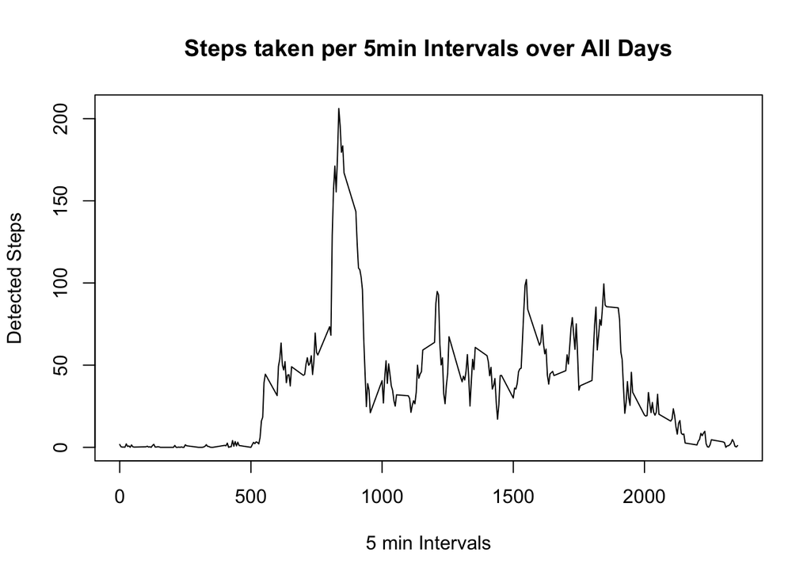

```r
steps_intMean <- aggregate(rmNA_activityData$steps, list(rmNA_activityData$interval), mean)

plot(steps_intMean, type ="l",xlab="5 min Intervals",ylab="Detected Steps",main = "Steps taken per 5min Intervals over All Days")
```

2. Which 5-minute interval, on average across all the days in the dataset, contains the maximum number of steps?

```r
max_int_steps <- max(steps_intMean$x)
steps_intMean$Group.1[steps_intMean$x == max_int_steps]
```

```
## [1] 835
```

## Imputing missing values

*Note that there are a number of days/intervals where there are missing values (coded as NA). The presence of missing days may introduce bias into some calculations or summaries of the data.*

1. Calculate and report the total number of missing values in the dataset (i.e. the total number of rows with NAs)

```r
sum(is.na(activityData$steps))
```

```
## [1] 2304
```

2. Devise a strategy for filling in all of the missing values in the dataset. The strategy does not need to be sophisticated. For example, you could use the mean/median for that day, or the mean for that 5-minute interval, etc.

My strategy relies on whether all the NAs are found in specific days. If all the values for a given day are NA, then I will set all of the step values to the mean step value for the corresponding interval. If there are NA values interspersed within days of recording, they will be replaced with the mean number of steps taken that interval over all the days.

3. Create a new dataset that is equal to the original dataset but with the missing data filled in.

```r
# Find the daily means
actIntvlMean<-aggregate(activityData$steps, by=list(interval=activityData$interval), FUN=mean, na.rm=TRUE)
actDateMean<-aggregate(activityData$steps, by=list(date=activityData$date), FUN=mean, na.rm=FALSE)
actDateSum<-aggregate(activityData$steps, by=list(date=activityData$date), FUN=sum, na.rm=FALSE)

# There are 8 days where no data was collected. All other days hold complete datasets. This factors into the following logic
sum(is.na(actDateMean$x))
```

```
## [1] 8
```

```r
sum(is.na(actDateSum$x))
```

```
## [1] 8
```

```r
mod_activityData <- activityData
mod_activityData$steps<-as.numeric(mod_activityData$steps)


# If the mean date for that specific day has a mean of NA, set that interval to the mean interval
j <- 1
for(i in 1:nrow(mod_activityData)){
    if(is.na(actDateMean$x[which(actDateMean$date == mod_activityData$date[i])])){
            mod_activityData$steps[i] <- actIntvlMean$x[j]
            j <- j+1
            if(j==289){j<-1}
    } else {
        mod_activityData$steps[i] <- activityData$steps[i]
    }
}
sum(is.na(mod_activityData$steps))
```

```
## [1] 0
```

4. Make a histogram of the total number of steps taken each day and Calculate and report the mean and median total number of steps taken per day. Do these values differ from the estimates from the first part of the assignment? What is the impact of imputing missing data on the estimates of the total daily number of steps?

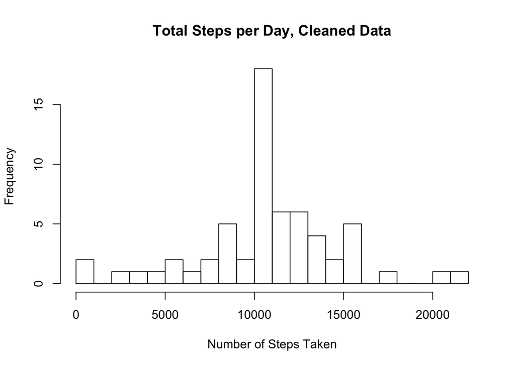

```r
mod_activity_DateSum<-aggregate(mod_activityData$steps,by=list(mod_activityData$date),FUN=sum)
mod_activity_DateMean<-aggregate(mod_activityData$steps,by=list(mod_activityData$date),FUN=mean)
colnames(mod_activity_DateMean) <- c("date","steps")


hist(mod_activity_DateSum$x,xlab="Number of Steps Taken",ylab="Frequency",main="Total Steps per Day, Cleaned Data",breaks = 20)
```

```r
mean(mod_activity_DateSum$x,na.rm = TRUE)
```

```
## [1] 10766.19
```

```r
median(mod_activity_DateSum$x,na.rm = TRUE)
```

```
## [1] 10766.19
```

Given my strategy, the effect of NA values seems to be made minimal.